# Socioeconomic Factors and Disease

by

Chetan Munugala

## Background

When looking for the causes of disease, we often focus on the individual and their personal health markers. However, the environment and circumstances that an individual finds themselves in may also contribute to disease outcomes. In this project, I explore various socioeconomic factors and how they correlate with disease.

Below you will find Python code that I used to compile, clean, visualize, and analyze relevant data, along with explanations of what I am doing. Additional information is included in the README file in the same folder as this project.

## Data Import and Cleaning

I begin by importing necessary packages, reading csv files with the necessary data into data frames (links in README), and cleaning the data. This cleaning process involves dropping irrelevant data, standardizing naming conventions within my data frame, splitting strings on appropriate characters, and more.

```python
import numpy as np
import pandas as pd
import matplotlib.pyplot as plt
import seaborn as sns
import re as re
from scipy import stats
import warnings
```

```python
#ignoring certain warnings to make jupyter notebook presentation more elegant

warnings.simplefilter('ignore')
```

```python
#importing all csv files containing data from links in README

income = pd.read_csv('Income Level.csv')
wilderness = pd.read_csv('Area of Wilderness.csv')
depression = pd.read_csv('Depression Rates.csv')
education = pd.read_csv('Education by State.csv')
heartattack = pd.read_csv('Heart Attack by State.csv')
natlparks = pd.read_csv('National Parks.csv')
unemployment = pd.read_csv('Unemployment Rate by State.csv')
cancer = pd.read_csv('Cancer Mortality by State.csv')
heartdisease = pd.read_csv('Heart Disease by State.csv')
suicide = pd.read_csv('Suicide by State.csv')
crime = pd.read_csv('Violent Crime by State.csv')
```

```python
states = {'AK': 'Alaska','AL': 'Alabama', 'AR': 'Arkansas','AS': 'American Samoa','AZ': 'Arizona','CA': 'California','CO': 'Colorado',
          'CT': 'Connecticut','DC': 'District of Columbia','DE': 'Delaware','FL': 'Florida','GA': 'Georgia','GU': 'Guam','HI': 'Hawaii',
          'IA': 'Iowa','ID': 'Idaho','IL': 'Illinois','IN': 'Indiana','KS': 'Kansas','KY': 'Kentucky', 'LA': 'Louisiana',
          'MA': 'Massachusetts','MD': 'Maryland','ME': 'Maine','MI': 'Michigan','MN': 'Minnesota','MO': 'Missouri','MP': 'Northern Mariana Islands',
          'MS': 'Mississippi','MT': 'Montana','NA': 'National','NC': 'North Carolina','ND': 'North Dakota','NE': 'Nebraska',
          'NH': 'New Hampshire','NJ': 'New Jersey','NM': 'New Mexico','NV': 'Nevada','NY': 'New York','OH': 'Ohio',
          'OK': 'Oklahoma','OR': 'Oregon','PA': 'Pennsylvania','PR': 'Puerto Rico','RI': 'Rhode Island','SC': 'South Carolina',
          'SD': 'South Dakota','TN': 'Tennessee','TX': 'Texas','UT': 'Utah','VA': 'Virginia','VI': 'Virgin Islands',
          'VT': 'Vermont','WA': 'Washington','WI': 'Wisconsin','WV': 'West Virginia','WY': 'Wyoming'}
```

```python
income.head()
```

|  | Rank | State or territory | Per capita income | Median household income | Median family income | Population | Number of households | Number of families |
| --- | --- | --- | --- | --- | --- | --- | --- | --- |
| 0 | 1.0 | District of Columbia | $45,877 | $71,648 | $84,094 | 658,893 | 277,378 | 117,864 |
| 1 | 2.0 | Connecticut | $39,373 | $70,048 | $88,819 | 3,596,677 | 1,355,817 | 887,263 |
| 2 | 3.0 | New Jersey | $37,288 | $69,160 | $87,951 | 8,938,175 | 2,549,336 | 1,610,581 |
| 3 | 4.0 | Massachusetts | $36,593 | $71,919 | $88,419 | 6,938,608 | 3,194,844 | 2,203,675 |
| 4 | 5.0 | Maryland | $36,338 | $73,971 | $89,678 | 5,976,407 | 2,165,438 | 1,445,972 |

```python
income.drop(['Rank','Number of households','Number of families','Median family income',],axis=1,inplace = True)
```

```python
income.rename(columns={'State or territory':'State'},inplace=True)
income.set_index('State',inplace=True)
```

```python
state_data = pd.DataFrame()
state_data = state_data.append(income)
```

Here, I created a data frame called state_data, which will eventually hold all of my relevant information. I added the cleaned income data frame to state_data and will proceed to do so for the rest of my categories.

Below you will find code for cleaning up the rest of the data frames containing my imported data.

```python
wilderness.drop(['Wilderness','Located in','Agency','Size (ha)','Designated'],axis=1,inplace=True)
wilderness = wilderness[~wilderness.State.str.contains(',')]
wilderness = wilderness.replace({'State':states})
wilderness['Size (acres)'] = wilderness['Size (acres)'].str.replace(',','')
wilderness['Size (acres)'] = pd.to_numeric(wilderness['Size (acres)'],downcast = 'integer')
wilderness = wilderness.groupby(['State']).sum()
wilderness.rename(columns={'Size (acres)':'Acres of Wilderness'},inplace=True)
```

```python
depression.drop(['Rank','% Change in Depression Rate','Access Rank'],axis=1,inplace=True)
depression.set_index('State',inplace=True)
depression.rename(columns={'Depression Rate':'Depression Rate (%)'},inplace=True)
```

```python
education.drop(['% High school graduate or higher','High School rank',"Bachelor's rank",'% Advanced degree',
                'Advanced rank'],axis=1,inplace=True)
education.rename(columns={'State, federal district, or territory':'State'},inplace=True)
```

```python
heartattack.drop(['RANK'],axis=1,inplace=True)
heartattack.rename(columns={'VALUE':'% Heart Attack in Adults','STATE':'State'},inplace=True)
heartattack.head()
heartattack.set_index('State',inplace=True)
```

```python
natlparks['Location'] = natlparks['Location'].apply(lambda x:re.split(r'(^[^\d]+)', x)[1])
natlparks.drop(['Name','Image','Date established as park[5][10]','Recreation visitors (2018)[8]','Description'],axis=1,inplace=True)
natlparks.rename(columns={'Location':'State','Area (2019)[11]':'Acres of National Park'},inplace=True)
natlparks['Acres of National Park'] = natlparks['Acres of National Park'].apply(lambda x: x.split(' ')[0])
natlparks['Acres of National Park'] = natlparks['Acres of National Park'].str.replace(',','')
natlparks['Acres of National Park'] = pd.to_numeric(natlparks['Acres of National Park'],downcast = 'integer')
natlparks = natlparks[~natlparks.State.str.contains(',')]
natlparks.set_index('State',inplace=True)
natlparks = natlparks.groupby(['State']).sum()
```

```python
unemployment.drop(['Rank'],axis=1,inplace=True)
unemployment.rename(columns={'Unemployment Rate':'Unemployment Rate (%)'})
unemployment.set_index('State',inplace=True)
```

```python
cancer = cancer.loc[cancer['YEAR'] == 2018]
cancer.drop(['YEAR','DEATHS','URL'],axis=1,inplace=True)
cancer.rename(columns={'STATE':'State','RATE':'Cancer Deaths per 100,000 Persons'},inplace=True)
cancer = cancer.replace({'State':states})
cancer.set_index('State',inplace=True)
```

```python
heartdisease['VALUE'] = heartdisease['VALUE']*100
heartdisease.rename(columns={'STATE':'State','VALUE':'%Heart Disease in Adults'},inplace=True)
heartdisease.drop('RANK',axis=1,inplace=True)
heartdisease.set_index('State',inplace=True)
```

```python
suicide.rename(columns={'STATE':'State','VALUE':'Suicide Deaths per 100,000 Persons'},inplace=True)
suicide.drop('RANK',axis=1,inplace=True)
suicide.set_index('State',inplace=True)
```

```python
crime.rename(columns={'STATE':'State','VALUE':'Violent Crimes per 100,000 Persons'},inplace=True)
crime.drop('RANK',axis=1,inplace=True)
crime.set_index('State',inplace=True)
```

```python
state_data = pd.merge(state_data,wilderness,how='outer',on='State')
state_data = pd.merge(state_data,depression,how='outer',on='State')
state_data = pd.merge(state_data,education,how='outer',on='State')
state_data = pd.merge(state_data,heartattack,how='outer',on='State')
state_data = pd.merge(state_data,natlparks,how='outer',on='State')
state_data = pd.merge(state_data,unemployment,how='outer',on='State')
state_data = pd.merge(state_data,cancer,how='outer',on='State')
state_data = pd.merge(state_data,heartdisease,how='outer',on='State')
state_data = pd.merge(state_data,suicide,how='outer',on='State')
state_data = pd.merge(state_data,crime,how='outer',on='State')
state_data.set_index('State',inplace=True)
state_data.drop(['United States[21]','District of Columbia','Guam','Puerto Rico','Northern Mariana Islands','American Samoa','U.S. Virgin Islands','United States'],inplace=True)
```

Now I have successfully cleaned the data and put all of the information I am investigating into one data frame - state_data. In the process, I dropped some territories of the United States because there was a lot of missing data. Next, we must figure out how to deal with the remaining missing pieces of data in the data frame above.

In this instance, we fill the missing values for Acres of Wilderness and Acres of National Park with zero because as far as I can tell, they were zero because there is no designation for them within those states.

```python
state_data['Acres of Wilderness'].fillna(value=0,inplace=True)
state_data['Acres of National Park'].fillna(value=0,inplace=True)
```

```python
state_data.head()
```

| State | Per capita income | Median household income | Population | Acres of Wilderness | Depression Rate (%) | % Bachelor's degree or higher | % Heart Attack in Adults | Acres of National Park | Unemployment Rate | Cancer Deaths per 100,000 Persons | %Heart Disease in Adults | Suicide Deaths per 100,000 Persons | Violent Crimes per 100,000 Persons |
| --- | --- | --- | --- | --- | --- | --- | --- | --- | --- | --- | --- | --- | --- |
| Connecticut | $39,373 | $70,048 | 3,596,677 | 0.0 | 16.98% | 38.40% | 3.70% | 0.0 | 3.7 | 134.1 | 3.7 | 10.9 | 207.0 |
| New Jersey | $37,288 | $69,160 | 8,938,175 | 10341.0 | 12.98% | 38.10% | 4.10% | 0.0 | 3.8 | 141.3 | 3.7 | 8.7 | 208.0 |
| Massachusetts | $36,593 | $71,919 | 6,938,608 | 3244.0 | 19.56% | 42.10% | 4.10% | 0.0 | 2.8 | 142.8 | 3.5 | 9.7 | 338.0 |
| Maryland | $36,338 | $73,971 | 5,976,407 | 0.0 | 16.12% | 39.00% | 3.90% | 0.0 | 3.3 | 149.9 | 4.1 | 10.3 | 469.0 |
| New Hampshire | $34,691 | $66,532 | 1,326,813 | 175989.0 | 21.54% | 36.00% | 4.40% | 0.0 | 2.6 | 143.7 | 3.8 | 19.2 | 173.0 |

At this point, we want to do some exploratory data analysis and visualization to see if there are any interesting relationships between the data. However, we must first convert all values into a format appropriate for graphing with the seaborn library.

• First, we must get rid of any extra punctuation such as dollar signs, commas, and percent signs.  
• Second, we must convert all strings to numeric values. The code to achieve this is shown below.

```python
state_data['Per capita income'] = state_data['Per capita income'].str.replace('$','')
state_data['Per capita income'] = state_data['Per capita income'].str.replace(',','')
state_data['Per capita income'] = pd.to_numeric(state_data['Per capita income'],downcast = 'integer')

state_data['Median household income'] = state_data['Median household income'].str.replace('$','')
state_data['Median household income'] = state_data['Median household income'].str.replace(',','')
state_data['Median household income'] = pd.to_numeric(state_data['Median household income'],downcast = 'integer')

state_data['Depression Rate (%)'] = state_data['Depression Rate (%)'].str.replace('%','')
state_data['Depression Rate (%)'] = pd.to_numeric(state_data['Depression Rate (%)'],downcast = 'integer')

state_data["% Bachelor's degree or higher"] = state_data["% Bachelor's degree or higher"].str.replace('%','')
state_data["% Bachelor's degree or higher"] = pd.to_numeric(state_data["% Bachelor's degree or higher"],downcast = 'integer')

state_data["% Heart Attack in Adults"] = state_data["% Heart Attack in Adults"].str.replace('%','')
state_data["% Heart Attack in Adults"] = pd.to_numeric(state_data["% Heart Attack in Adults"],downcast = 'integer')

state_data.head()
```

| State | Per capita income | Median household income | Population | Acres of Wilderness | Depression Rate (%) | % Bachelor's degree or higher | % Heart Attack in Adults | Acres of National Park | Unemployment Rate | Cancer Deaths per 100,000 Persons | %Heart Disease in Adults | Suicide Deaths per 100,000 Persons | Violent Crimes per 100,000 Persons |
| --- | --- | --- | --- | --- | --- | --- | --- | --- | --- | --- | --- | --- | --- |
| Connecticut | 39373 | 70048 | 3,596,677 | 0.0 | 16.98 | 38.4 | 3.7 | 0.0 | 3.7 | 134.1 | 3.7 | 10.9 | 207.0 |
| New Jersey | 37288 | 69160 | 8,938,175 | 10341.0 | 12.98 | 38.1 | 4.1 | 0.0 | 3.8 | 141.3 | 3.7 | 8.7 | 208.0 |
| Massachusetts | 36593 | 71919 | 6,938,608 | 3244.0 | 19.56 | 42.1 | 4.1 | 0.0 | 2.8 | 142.8 | 3.5 | 9.7 | 338.0 |
| Maryland | 36338 | 73971 | 5,976,407 | 0.0 | 16.12 | 39.0 | 3.9 | 0.0 | 3.3 | 149.9 | 4.1 | 10.3 | 469.0 |
| New Hampshire | 34691 | 66532 | 1,326,813 | 175989.0 | 21.54 | 36.0 | 4.4 | 0.0 | 2.6 | 143.7 | 3.8 | 19.2 | 173.0 |

## Exploratory Data Visualization and Analysis

Now we are ready to visualize our data. I begin by using two general plot types, pairplot and clustermap, to quickly look over relationships between data and see which relationships I want to further explore.

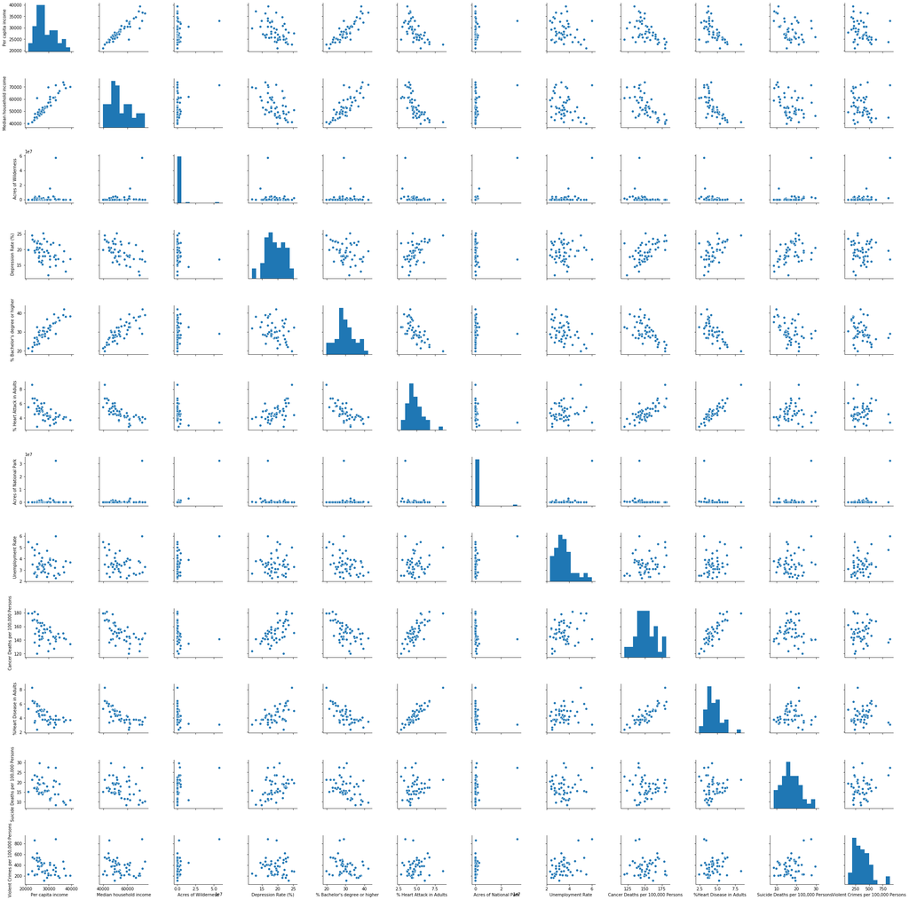

```python
sns.pairplot(state_data)
```

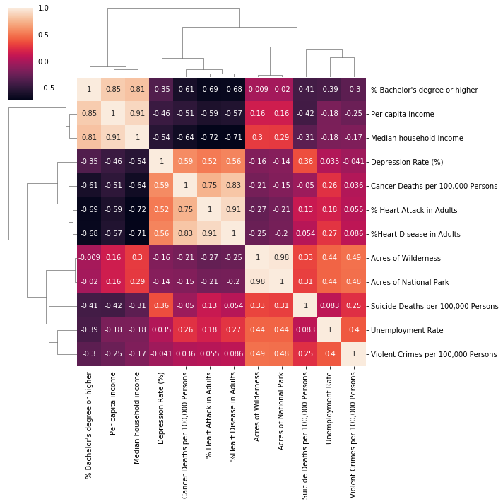

```python
sns.clustermap(state_data.corr(),annot=True)
```

Although there are many relationships we can explore, to avoid making this notebook too long, I will explore the three that were most interesting to me. Those are:

1. Effects of Income on Disease
2. Effects of Nature Accesibility on Disease
3. Effects of Education on Disease

### Effects of Income on Disease

```python
#code to make a table with pearson r values for correlations between variables with per capita income

Depression = state_data['Median household income'].corr(state_data['Depression Rate (%)'])
Heart_Attack = state_data['Median household income'].corr(state_data['% Heart Attack in Adults'])
Cancer_Deaths = state_data['Median household income'].corr(state_data['Cancer Deaths per 100,000 Persons'])
Heart_Disease = state_data['Median household income'].corr(state_data['%Heart Disease in Adults'])

DepressionP = state_data['Per capita income'].corr(state_data['Depression Rate (%)'])
Heart_AttackP = state_data['Per capita income'].corr(state_data['% Heart Attack in Adults'])
Cancer_DeathsP = state_data['Per capita income'].corr(state_data['Cancer Deaths per 100,000 Persons'])
Heart_DiseaseP = state_data['Per capita income'].corr(state_data['%Heart Disease in Adults'])

corrs = pd.DataFrame((Depression,Heart_Attack,Cancer_Deaths,Heart_Disease),columns=['Median Household Income (pearsonr)'])
corrs['Per Capita Income (pearsonr)'] = [DepressionP,Heart_AttackP,Cancer_DeathsP,Heart_DiseaseP]
corrs['']= ['Depression','Heart Attack','Cancer Deaths','Heart Disease']
corrs.set_index('',inplace=True)
```

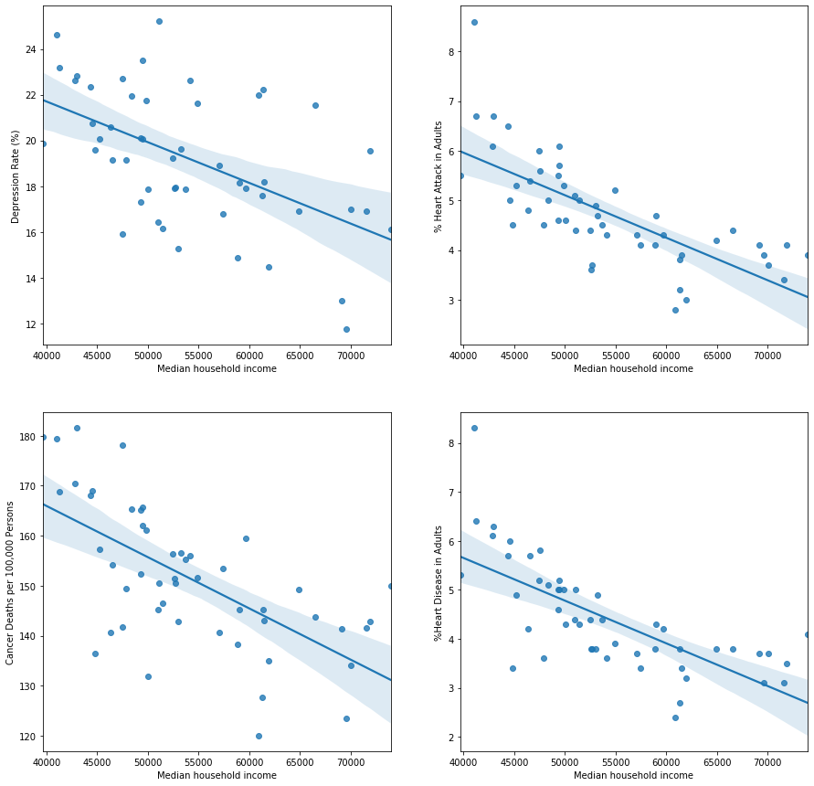

```python
#plot four subplots showing relationships between variables

fig, axs = plt.subplots(nrows=2,ncols=2,figsize=(15,15))
sns.regplot(x='Median household income',y='Depression Rate (%)',data=state_data,ax=axs[0][0])
sns.regplot(x='Median household income',y='% Heart Attack in Adults',data=state_data,ax=axs[0][1])
sns.regplot(x='Median household income',y='Cancer Deaths per 100,000 Persons',data=state_data,ax=axs[1][0])
sns.regplot(x='Median household income',y='%Heart Disease in Adults',data=state_data,ax=axs[1][1])
```

As we can see from the correlation data and the visualizations, as median household income decreases we see an increase in depression, heart attacks, cancer deaths, and heart disease. This data suggests that having financial resources can help to increase health with regards to these conditions. I could speculate many reasons why this may be the case, but a deeper dive is required to find out with certainty.

```python
corrs
```

|  | Median Household Income (pearsonr) | Per Capita Income (pearsonr) |
| --- | --- | --- |
| Depression | -0.536394 | -0.455101 |
| Heart Attack | -0.720379 | -0.589971 |
| Cancer Deaths | -0.641760 | -0.509000 |
| Heart Disease | -0.711137 | -0.571779 |

Additionally, we can see in the table above that Median Household Income is more strongly correlated with each of these diseases than Per Capita Income. This suggests that what a group of individuals living together is making is more important than what an individual is making.

### Effects of Nature Accesibility on Disease

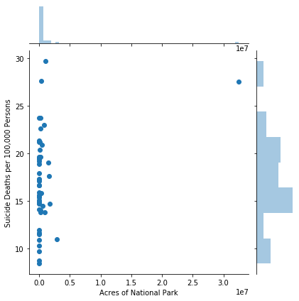

```python
sns.jointplot(x=state_data['Acres of National Park'],y=state_data['Suicide Deaths per 100,000 Persons'])
```

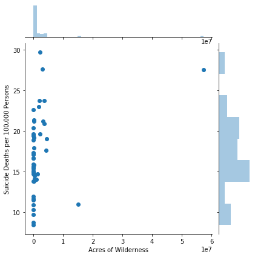

```python
sns.jointplot(x=state_data['Acres of Wilderness'],y=state_data['Suicide Deaths per 100,000 Persons'])
```

```python
no_outliers = state_data[(state_data['Acres of Wilderness']< 1.4e7) & (state_data['Acres of National Park'] < 2e6)]
```

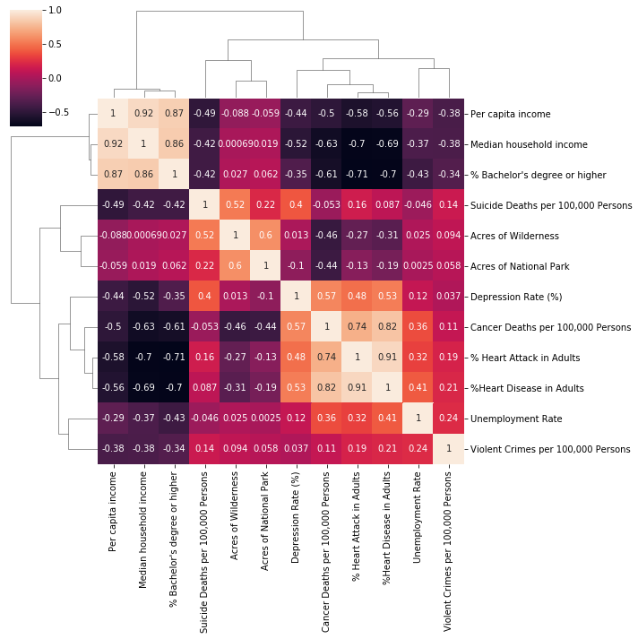

```python
sns.clustermap(no_outliers.corr(),annot=True)
```

As you can see, the clustering of these variables changed along with the correlation coefficients for the "Acres of Wilderness" and "Acres of National Park" columns. Specifically, there seem to be interesting relationships between these variables and "Cancer Deaths per 100,000 Persons" and "Suicide Deaths per 100,000 Persons".

```python
#code to make a table with pearson r values for correlations between variables with cancer deaths

Wilderness = no_outliers["Acres of Wilderness"].corr(no_outliers['Cancer Deaths per 100,000 Persons'])
National_Parks = no_outliers["Acres of National Park"].corr(no_outliers['Cancer Deaths per 100,000 Persons'])

corrs = pd.DataFrame((Wilderness, National_Parks),columns=['Cancer Deaths (pearsonr)'])
corrs['']= ['Acres of Wilderness', 'Acres of National Park']
corrs.set_index('',inplace=True)
```

|  | Cancer Deaths (pearsonr) |
| --- | --- |
| Acres of Wilderness | -0.461495 |
| Acres of National Park | -0.440889 |

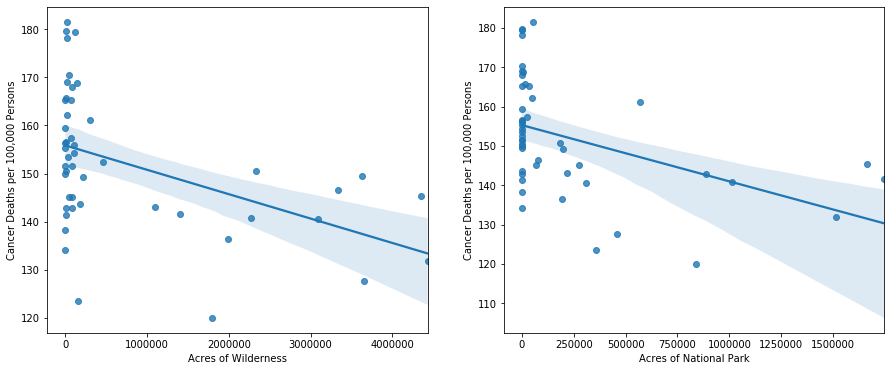

```python
#plot two subplots showing relationships between variables


fig, axs = plt.subplots(nrows=1,ncols=2,figsize=(15,6))


sns.regplot(x='Acres of Wilderness',y='Cancer Deaths per 100,000 Persons',data=no_outliers,ax=axs[0])
sns.regplot(x='Acres of National Park',y='Cancer Deaths per 100,000 Persons',data=no_outliers,ax=axs[1])

corrs
```

As you can see from the plots above, Cancer Deaths seem to go down as the Acres of Wilderness and National Parks go up in a given state. However, we must take this with a grain of salt because of the minimum number of data points. Still, it is an interesting observation and is an area I would like to explore in more detail in the future.

```python
Wilderness = no_outliers["Acres of Wilderness"].corr(no_outliers['Suicide Deaths per 100,000 Persons'])
```

```
Pearson_R: 0.5219809174174719
```

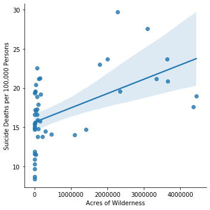

```python
sns.lmplot(x='Acres of Wilderness',y='Suicide Deaths per 100,000 Persons',data=no_outliers)
print('Pearson_R:',Wilderness)
```

Interestingly, suicide deaths seem to go up as Acres of Wilderness in a state goes up. When starting this project, one of hypotheses was that people who spent more time in nature were more healthy, especially when it came to mental health. For that reason, this result is surprising to me and definitely worth looking at again.

### Effects of Having a Bachelors Degree on Disease

```python
#code to make a table with pearson r values for correlations between variables with education

Depression = state_data["% Bachelor's degree or higher"].corr(state_data['Depression Rate (%)'])
Heart_Attack = state_data["% Bachelor's degree or higher"].corr(state_data['% Heart Attack in Adults'])
Cancer_Deaths = state_data["% Bachelor's degree or higher"].corr(state_data['Cancer Deaths per 100,000 Persons'])
Heart_Disease = state_data["% Bachelor's degree or higher"].corr(state_data['%Heart Disease in Adults'])
Suicide_Deaths = state_data["% Bachelor's degree or higher"].corr(state_data['Suicide Deaths per 100,000 Persons'])


corrs = pd.DataFrame((Depression,Heart_Attack,Cancer_Deaths,Heart_Disease,Suicide_Deaths),columns=['Bachelors degree or higher (pearsonr)'])
corrs['']= ['Depression','Heart Attack','Cancer Deaths','Heart Disease','Suicide Deaths']
corrs.set_index('',inplace=True)
```

|  | Bachelors degree or higher (pearsonr) |
| --- | --- |
| Depression | -0.351254 |
| Heart Attack | -0.687355 |
| Cancer Deaths | -0.608123 |
| Heart Disease | -0.684748 |
| Suicide Deaths | -0.413785 |

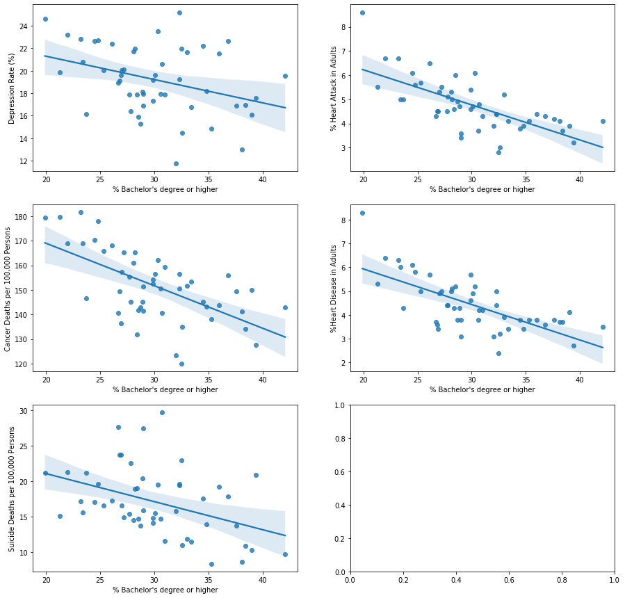

```python
#plot five subplots showing relationships between variables

fig, axs = plt.subplots(nrows=3,ncols=2,figsize=(15,15))
sns.regplot(x="% Bachelor's degree or higher",y='Depression Rate (%)',data=state_data,ax=axs[0][0])
sns.regplot(x="% Bachelor's degree or higher",y='% Heart Attack in Adults',data=state_data,ax=axs[0][1])
sns.regplot(x="% Bachelor's degree or higher",y='Cancer Deaths per 100,000 Persons',data=state_data,ax=axs[1][0])
sns.regplot(x="% Bachelor's degree or higher",y='%Heart Disease in Adults',data=state_data,ax=axs[1][1])
sns.regplot(x="% Bachelor's degree or higher",y='Suicide Deaths per 100,000 Persons',data=state_data,ax=axs[2][0])

corrs
```

Clearly, based on these visualizations and correlation data, having a bachelor's degree or higher level education is correlated with a lower rate of these conditions, especially for heart attacks, cancer deaths, and heart disease.

## Conclusion and Future Directions

By exploring this data, I found interesting correlations that lead to interesting personal projects in the future. However, my methods here were limited by my knowledge of statistics and data science, as I am sure there exist more tools that I could use explore this data. As I progress in my data science career, I will revisit this project and see if I can extract more meaningful insights from this data.

In the interest of keeping this notebook as succinct as possible, I did not explore relationships between socioeconomic factors and between diseases. However, I did see some potentially interesting correlations such as the relationship between depression and heart conditions, and violent crimes and acres of wilderness.

Finally, I did not train a model on this data as I did not see the utility of a model in this scenario. However, as I refine my data skills I will revisit this data and see if there is a reason to utilize machine learning.